# Estimating power in linear and generalized linear mixed models: an open introduction and tutorial in R.

Kumle, L., Vo, M. L-H.., & Draschkow, D.

latest update: March 2019

## Scenario 1: using fitted model from published data

Sufficient power and precision in confirmatory analyses are important for the reliability, replicability, and interpretation of empirical findings. Calculating power, however, is not necessarily a trivial task and in certain cases this might pose a feasibility barrier to scientists. One of these cases is power analysis for liner mixed-effect models (LMMs). LMMs are a powerful tool for modeling fixed and random effects simultaneously, but do not offer a feasible analytic solution to estimate the probability that a test correctly rejects the null hypothesis.

A flexible and more intuitive alternative approach are simulation-based power analyses which can use a linear-mixed model fitted with *lme4* (Bates, Maechler, Bolker & Walker, 2015) to inform the parameters of the simulation. For more details on the theoretical background see Kumle, Vo & Draschkow (in preparation).

In this notebook we outline a scenario in which already published studies and data are available and used as a starting point. First, we will demonstrate how to estimate power for single effects using the SIMR package (Green & Macleod, 2016). Next, we will introduce the package [*mixedpower*](https://github.com/DejanDraschkow/mixedpower) (Kumle, Vo & Draschkow, 2018) to simulate power for all effects specified in a model simultaneously.

### **Import Data**

Data used for this tutorial originates from Yan, Zhou, Shu, Yusupu, Miao, Kruegel & Kliegl (2014). All analyses and data were obtained from http://read.psych.uni-potsdam.de where the authors made them available.

In their eye-tracking experiment, Yan et al. (2014) examined the influence of word length, launch site, morphological complexity and word frequency on first landing positions (FLP) during reading. The data contains 48 subjects, each of whom read 120 sentences.

We will use this data set to run a power analysis for a planned study investigating and confirming the influence of different parameters on first landing positions while reading.

To focus on the actual power analysis procedure we already preprocessed the data set according to the author’s analysis. This preprocessed data can be downloaded [here](https://www.dropbox.com/s/ply8xkg123d4ee0/Yan_et_al.RData?dl=0).

```r
# get data
load("Yan_et_al.RData") # data set is called "YanData"
```

Informing the parameters of the simulation is an extremely crucial step and this tutorial is aimed at GLMMs/LMMs fitted with lme4. A power analysis in this context therfor starts with a such a model. We will use the final model provided by Yan et al. (2014). The full analysis and data can be found at http://read.psych.uni-potsdam.de.

```r
library(lme4)
# final LMM to simulate power for
FLPmodel <- lmer(flp ~ wl.c * ls.c * sn.c +
                    (1+wl.c+ls.c+sn.c+wl.c:sn.c|nsub) + (1|nsen) + (1|wid),
                    data=data)
summary(FLPmodel, corr = F)
```

Some information about this data set and model:

```
 wl.c: centerd word length
 ls.c: centered launch site
 sn.c: centered number of suffixes
 nsub: subject ID variable
 nsen: sentence variable (stimulus)
 wid: variable coding the individual words
```

### **Power Analysis with SIMR**

First, we will simulate power for one specific effect in the FLPmodel using SIMR (Green & Macleod, 2016). For an extensive tutorial on the different functions and options included in SIMR see [Green & Macleod (2016)](https://doi.org/10.1111/2041-210X.12504) and the other notebooks included in the main tutorial (LINK to smobsc).

Let’s assume we are especially interested in the effect of word length and want to confirm it in our planned study. To justify and decide on a sample size for this study, we decide to run a power analysis.

To do so, we first need to install and load the SIMR package (Green & Macleod, 2016). Note that SIMR only needs to be installed once and loading the package is sufficient once it is installed.

```r
## install SIMR
install.packages("simr")
```

```r
# load SIMR
library(simr)
```

#### Running the power analysis

SIMR offers two easy-to-use functions which can be used to simulate and examine power in a mixed model. As we are interested in confirming the effect size of world length (= 1.587179), we will not modify this effect size and the model.

In a first step, we will simulate power for exactly the number of subjects and the specified effect size in the FLPmodel. For this, we can use the powerSim()-function. Explore ?powerSim for a treatment of all possible argument specification.

**Note**: SIMR can simulate power for only one effect at a time and as a default runs the simulation for the first effect specified in the model. Even though word length is the first effect specified in our FLPmodel, we chose to make it explcit for clarity.

```r
# run power analysis
power <- powerSim(fit = FLPmodel, test = fixed("wl.c"))
print(power)
```

[output not shown]

```r
# run power analysis
powerC <- powerCurve(fit = FLPmodel, test = fixed("wl.c"))
print(powerC)
```

[output not shown]

In conclusion, using SIMR can be especially useful if a researcher only is interested in specific effects as it is easy and straightforward to set up a power analysis for that. However, there are scenarios when a researcher is interested in more than one effect from a model. Running a seperate power analysis for every effect is time consuming and it would be more convenient to just simulate power for all effects at once.

As a second tool for simulation-based power analysis we therfor want to introduce the newly developed package [*mixedpower*](https://github.com/DejanDraschkow/mixedpower) (cite) which allows to simulate power for all effects in a model. Moreover, mixedpower includes the *safeguard power* option introduced by Perugini et al. (2014) to account for unreliable effect sizes.

In the following section, we will conduct a power analysis with mixedpower.

### **Power Analysis with mixedpower**

Similar to SIMR, the power analysis starts with a fitted model and again we will work with our FLPmodel. Again, mixedpower needs to be installed first. The package is hosted on [GitHub](https://github.com/DejanDraschkow/mixedpower) and the devtools package is required to install it.

```r
# install mixedpower package
if (!require("devtools")) {
    install.packages("devtools", dependencies = TRUE)}
devtools::install_github("DejanDraschkow/mixedpower")
```

#### **A function for calculating power**

Once the library is loaded, we can use the mixedpower() function to perform the power analysis.

```r
library(mixedpower)

#core function to perform power analysis
mixedpower(model_emp, data_emp, subvar, fixed_effects,
           sample_sizes, n_sim, critical_value, confidence_level,
           databased = T, safeguard = T, rnorm = F)
```

A general introduction to mixedpower can be found here. In the following section, we will specify all relevant parameters without going into detail of the inner working of mixedpower. To gain a better understanding on why each parameter is needed, we recommend reading the general introduction first.

#### **Empirical data and model**

We already loaded our data and specified a final model we want to work with. Accordently, we can use our fitted model (model_emp = FLPmodel) and our data frame as the data set (data_emp = YanData).

The function requires further specifics about the data at hand including the name of the collumn containing the subject identifier (subvar) and the names of the fixed effects specified in the model (fixed_effects).

```r
# specfiy needed information about data set
model_emp <- FLPmodel
data_emp <- YanData
subvar <- "nsub"
fixed_effects <- c("wl.c","ls.c", "sn.c")
```

#### **Simulation of multiple data sets**

As noted before, power in a simulation-based approach is computed as the proportion of significant simulations to all simulations. Thus, we need to define the number of simulations we want to run. We suggest running at least 1000 simulations (n_sim = 1000) but fewer runs can be used to check if the analysis is running smoothly.

```r
# simulation parameters
n_sim <- 1000
sample_sizes <- c(30, 40, 48, 60, 70)
```

#### **Test of statistical significance**

Deciding if an effect exceeds a significance threshold is a critical aspect of every simulation-based power analysis and heavily influences its outcome. In general, rising this threshold will lead to lower estimated power as it becomes harder to reach it and vice versa. Mixedpower relies on lme4, which does not provide p-values. Even though there are methods available to compute p-values in mixed models, they are affiliated with ambiguity because degrees of freedom are hard to determine in mixed models and mixedpower therefore works with the available t values for linear mixed models or z values for generalized linear mixed models. Concluding, we need to set a critical_value in form of a t or z values depending on the model on hand and all coefficients exceeding this value would be counted as significant. In the present example, we decided to set critical_value = 2.

```r
# set critical_value
critical_value <- 2
```

#### **Protection against bias in data**

The accuracy of a simulation-based calculation of power and its interpretability is dependent on how well the model is capturing the data (Thomas & Juanes, 1996) and on how well the data is capturing the underlying effect of interest. Especially data consisting of only few observations or participants, (e.g. from pilot or exploratory studies) carry the risk of uncertainty in respect to effects in the data.

Mixedpower adapted the safeguard option introduced by Perugini et al. (2014). For more background information see the main tutorial or the general introduction to mixedpower. As safeguard power in general is a confidemce interval around the beta coefficients, all we need to do to use it is to specify the width of this cinfidence interval. In the present example, we will set it to 0.68 representing the width of one standard deviation.

```r
# set width of confidence interval
confidence_level <- 0.68
```

#### **Power simulation**

We now can run the power simulation for the data at hand. For this, we will use the function mixedpower() which handles and combines simulations for all specified sample sizes and provides us with a power estimate derived from the actual effect sizes of the data (databased), as well as the conservative estimate of safeguard power (safeguard). The relevant parameters specified in the steps above will be used.

```r
power_output <- mixedpower(FLPmodel, YanData, subvar, fixed_effects,critical_value,
                           sample_sizes, n_sim, confidence_level,
                           databased = T, safeguard = T, rnorm = F)
```

#### **Interpreting and visualizing the power analysis**

The output provided by mixedpower() contains power values for every effect and all specified sample sizes. The power values are provided both from the original effect sizes (databased) or the corrected conservative estimates (safeguard).

```r
power_output
```

[output not shown]

What do we see here?

power_output contains power values for every effect and interactions for all sample sizes we specified. Additionaly, power_output includes the mode (databased and safeguard) to specify under which condition the simulation was run. Plotting the output allows us to better understand it.

**Note**: multiplotPower automatically saves the plot to the current working directory.

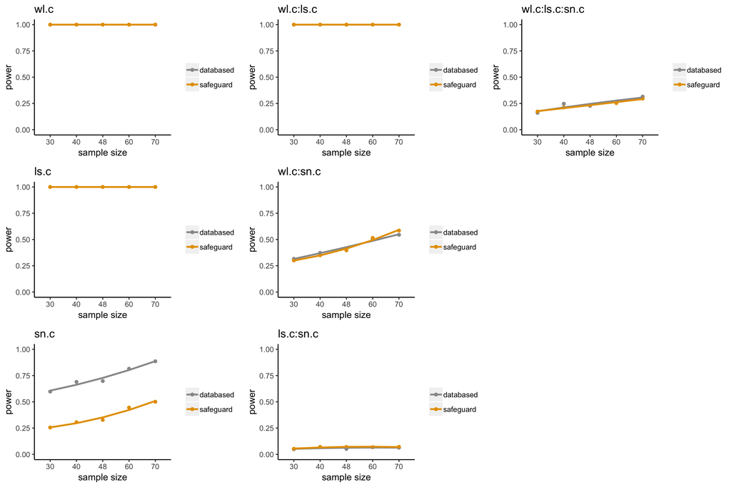

```r
# plot power_output
multiplotPower(power_output)
```

A separate graph for each effect in the model output is plotted. In the current example, the data consisted of 48 participants, thus each power value at 48 corresponds to the actual sample size of the data used to inform the simulation. The effect of word length (wf.c) and launch site (ls.c) as well as their interaction (wf.c:ls.c) had a power of 100%. Number of suffixes (sn.c) had a power of 70%, the interaction of word length and number of suffixes (wl.c:sn.c) had a power of 41, the interaction of all three main effects (wl.c:ls.c:sn.c) had a power of 23% and the interaction of launch site and number of suffixes (ls.c:sn.c) had a power of 5%.

Moreover, safeguard power seems to only make a difference for number of suffixes (sn.c). Because sagfeguard power only is available for significant effects in the model used for simulation (FLPmodel), safeguard was not effectivly used for wl.c:ls.c:sn.c, wl.c:sn.c and ls.c:sn.c.

#### **Deciding on a sample size**

Using the output of a power analysis to decide ona sample size requires making multiple decisions. First, we need to decide on a goal power. A well-known threshold value for the probability of finding an effect in cognitive neuroscience and psychology is 80% and represents a compromise between the need for adequate power and the effort/cost needed to further increase power (Brysbaert & Stevens, 2018). However, we emphasize that this does not reflect a fixed value and different thresholds may be more appropriate depending on the researcher???s goal( O???Brien & Castelloe, 2007).

In the current example we will still take 80% as the goal power.

Second, especially when working with mixedpower, we need to decide on which estimate (databased or safeguard) our decision should be based on and which effects are taken into consideration. As the current simulation was based on published data that are likely to be subject to pubilcation bias, using the safeguard power (in case it is available) estimate seems reasonable. Since mixedpower provides power estimates for all effects specified in the model, we need to aree on a strategy om how to combine this information. In doing so, different scenarios come to mind depending on how many effects are of interest. On general, of all effects of interest the one with lowest power should be picked to decide on a sample size for the following study to assure that all effects are adequatly powered.

### **References**

Bates, D., M??chler, M., Bolker, B., & Walker, S. (2014). Fitting Linear Mixed-Effects Models using lme4. Journal of Staistical Software, 67(1). https://doi.org/10.18637/jss.v067.i01

Kumle, L., Vo, M. L-H.., & Draschkow, D. (2018). Mixedpower: a library for estimating simulation-based power for mixed models in R. https://doi.org/10.5281/zenodo.1341047

Perugini, M., Gallucci, M., & Costantini, G. (2014). Safeguard Power as a Protection Against Imprecise Power Estimates. Perspectives on Psychological Science, 9(3), 319-332. https://doi.org/10.1177/1745691614528519

Yan, M., Zhou, W., Shu, H., Yusupu, R., Miao, D., Kruegel, A., & Kliegl, R. (2014). Eye movements guided by morphological structure: Evidence from the Uighur language. Cognition, 132(2), 181???215. https://doi.org/10.1016/j.cognition.2014.03.008